```python
import pandas as pd
import numpy as np
import seaborn as sns
import matplotlib
import math
import matplotlib.pyplot as plt
from scipy.stats import skew
from scipy.stats.stats import pearsonr

from sklearn import preprocessing
from sklearn.linear_model import Ridge, RidgeCV, ElasticNet, LassoCV, LassoLarsCV
from sklearn.model_selection import cross_val_score

from sklearn.metrics import mean_squared_error
from sklearn.datasets import make_blobs
from sklearn.neighbors import KNeighborsRegressor
from sklearn.model_selection import train_test_split

knn = KNeighborsRegressor(n_neighbors=7)
%config InlineBackend.figure_format = 'png' #set 'png' here when working on notebook
%matplotlib inline
```

```python
from google.colab import drive
drive.mount('/content/drive')
df = pd.read_csv ('/content/drive/MyDrive/mestrado/2022.2/aprendizagem_de_maquina_2022.2/2olab/eleicoes_2006_a_2010.csv')
df_2014 = pd.read_csv ('/content/drive/MyDrive/mestrado/2022.2/aprendizagem_de_maquina_2022.2/2olab/eleicoes_2014.csv')
```

# 2.1 - Analisar as distribuições das variáveis para ver se estão enviesadas e precisam de correção; tratamento de valores ausentes, variáveis categóricas e normalização, quando for o caso.

**Abaixo temos a retiradas dos NaN encontrados no meio dos dados, também há a separação dos dados de treino para os dados do ano de 2006 e 2010 e os dados de teste para os dados do ano de 2014**

```python
# Concatena os dados entre dos anos de 2006+2010 e 2014
df_all = pd.concat([df, df_2014], ignore_index=True)

#Retirando variáveis categoricas
df_all = df_all.drop(columns=["sequencial_candidato", "nome", "cargo"])

# Normaliza todos os valores
df_all = df_all.fillna(df_all.mean().round(1))
anos = df_all["ano"]
index = df_all.dtypes[df_all.dtypes != "object"].index

df_all[index] = np.log1p(df_all[index])
df_all = pd.get_dummies(df_all)

scaler = preprocessing.MinMaxScaler()
df_all[index] = scaler.fit_transform(df_all[index])
df_all["ano"] = anos


# Separa os dados de treino e teste
x_2010 = df_all[df_all["ano"] == 2010]
x_2006 = df_all[df_all["ano"] == 2006]
x_train = pd.concat([x_2010, x_2006], ignore_index=True)
x_test = df_all[df_all["ano"] == 2014]

# Separa os valores que devem ser feito a predição
y_train = x_train.votos
y_test = x_test.votos

# Remove valores dos dados de treino e validação
x_train = x_train.drop(columns=["ano","votos"])
x_test = x_test.drop(columns=["ano","votos"])
```

# 2.2 Construir modelos de regressão com (ridge e lasso)

```python
#Modelos abaixo:
model_lasso = LassoCV(cv=10).fit(x_train, y_train)
model_ridge = Ridge(alpha=1).fit(x_train, y_train)
```

Abaixo temos a acuracia de cada modelo:

```python
print('Score de treino em Lasso', model_lasso.score(x_train, y_train))
print('Score de Validação em Lasso', model_lasso.score(x_test, y_test))

print('Score de treino em Ridge', model_ridge.score(x_train, y_train))
print('Score de Validação em Ridge', model_ridge.score(x_test, y_test))
```

```
Score de treino em Lasso 0.7727459383277528
Score de Validação em Lasso -0.19053431083605776
Score de treino em Ridge 0.7789868208122119
Score de Validação em Ridge -0.2788891372527771
```

# 2.3 considerar outros modelos ainda não vistos em sala de sua escolha (e.g. SVR, Regression Trees, KNN e Random Florests).

Nesse caso escolhi o KNN como outro modelo.

```python
model_knn = knn.fit(x_train, y_train)
print('Score de treino em KNN', model_knn.score(x_train, y_train))
print('Score de Validação em KNN', model_knn.score(x_test, y_test))
```

```
Score de treino em KNN 0.7477301429312417
Score de Validação em KNN 0.08756686867662067
```

# 2.5 Plotar os resíduos versus predições e analisar se esses plots representam bons indícios da adequabilidade dos modelos a esse problema.

[figure not shown]

```python
lasso_results = model_ridge.predict(x_test)
plt.subplots(figsize=(18, 10))
plt.subplot(211)
plt.title("Predição - Lasso")
plt.plot(range(len(lasso_results)), lasso_results)

plt.subplot(212)
plt.title("Valores Reais")
plt.plot(range(len(y_test)), y_test)
```

```
Lasso retirou 104 variáveis e eliminou outras 5319 variáveis
```

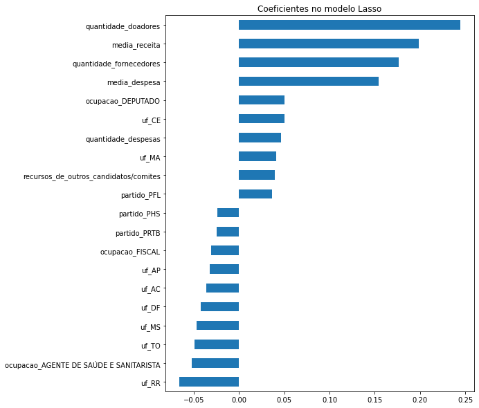

```python
coef = pd.Series(model_lasso.coef_, index = x_train.columns)
print("Lasso retirou " + str(sum(coef != 0)) + " variáveis e eliminou outras " +  str(sum(coef == 0)) + " variáveis")
imp_coef = pd.concat([coef.sort_values().head(10),
                     coef.sort_values().tail(10)])
matplotlib.rcParams['figure.figsize'] = (8.0, 10.0)
imp_coef.plot(kind = "barh")
plt.title("Coeficientes no modelo Lasso")
```

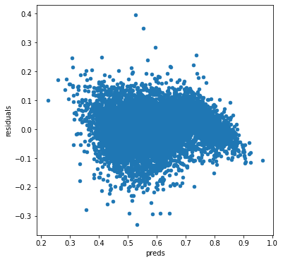

```python
matplotlib.rcParams['figure.figsize'] = (6.0, 6.0)
preds = pd.DataFrame({"preds":model_lasso.predict(x_train), "true":y_train})
preds["residuals"] = preds["true"] - preds["preds"]
preds.plot(x = "preds", y = "residuals",kind = "scatter")
```

## Abaixo temos a comparação da Predição e dos valores reais no modelo Ridge

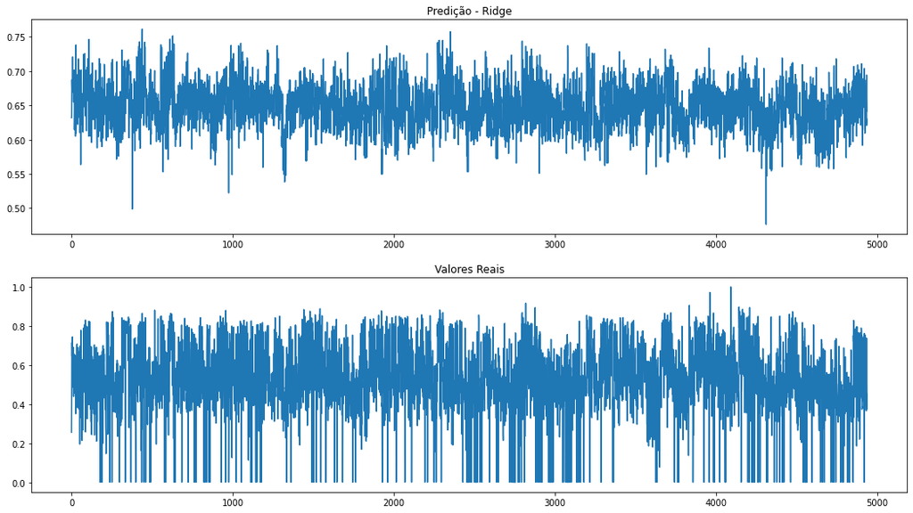

```python
ridge_results = model_ridge.predict(x_test)
plt.subplots(figsize=(18, 10))
plt.subplot(211)
plt.title("Predição - Ridge")
plt.plot(range(len(ridge_results)), ridge_results)

plt.subplot(212)
plt.title("Valores Reais")
plt.plot(range(len(y_test)), y_test)
```

```
Ridge retirou 264 variáveis e eliminou outras 5159 variáveis
```

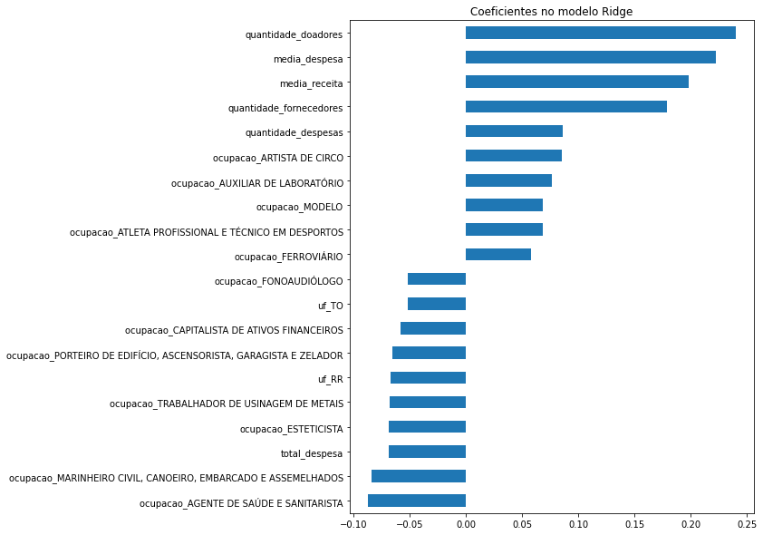

```python
coef = pd.Series(model_ridge.coef_, index = x_train.columns)
print("Ridge retirou " + str(sum(coef != 0)) + " variáveis e eliminou outras " +  str(sum(coef == 0)) + " variáveis")
imp_coef = pd.concat([coef.sort_values().head(10),
                     coef.sort_values().tail(10)])
matplotlib.rcParams['figure.figsize'] = (8.0, 10.0)
imp_coef.plot(kind = "barh")
plt.title("Coeficientes no modelo Ridge")
```

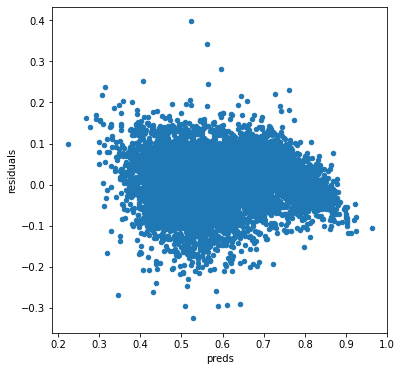

```python
matplotlib.rcParams['figure.figsize'] = (6.0, 6.0)
preds = pd.DataFrame({"preds":model_ridge.predict(x_train), "true":y_train})
preds["residuals"] = preds["true"] - preds["preds"]
preds.plot(x = "preds", y = "residuals",kind = "scatter")
```